# AMP - Designing an RCT

RCT design and early data checks

Michael Barber

July 17th, 2017

# 1 AMP lesson: RCT principles

## 1.1 Glossary and key terms:

- **Cluster**: A group of individuals sharing some co-variates.
- **Randomisation unit**: The level at which randomization (and analysis) occurs, this could be the individual, the group, or the site (or other levels)
- **Outliers**: Data points which do not seem to follow the main distribution, note that this is often very subjective.
- **Scientific writing**: A style of writing that makes work transparent and communicable to other analysts
- **Treatment group**: Those individuals or clusters that have been assigned to an intervention
- **Control group**: Those individuals or clusters that have been assigned to not receive an intervention
- **Co-variate** : Other variables in a study that may correlate with your outcome

## 1.2 Lesson objectives:

> Motivation:

This lesson will explore the randomized controlled trial as a statistical tool. We will look at how to effectively plan and understand an RCT, and how to conduct early checks on RCT data to ensure it is proceeding as planned.

## 1.3 Principles of Randomised controlled trials

The RCT is a key tool for any analyst, what separates the RCT from other statistical tools is its ability to define causality. Whereas most statistical techniques can only tell us about *correlations*, the RCT can tell us about causation, i.e. whether A causes B or B causes A. As such, the RCT is central to proving what does and does not work for our farmers.

Each RCT will have a some common elements:

- **Hypothesis**: A proposition (or statement) to evaluate.
- **Hypothesis test**: This is the tool we will use to assess the hypothesis
- **Randomization**: The random assignment of individuals or groups to a treatment or control group
- **A control group**: a randomly selected group assigned to *not* receive the intervention
- **A treatment group** a randomly selected group assigned to receive the intervention. It is possible to have multiple treatment groups in an RCT, one for each intervention.

Let us examine these concepts in turn.

### 1.3.1 The Hypothesis

Each RCT is generally set up to test a *hypothesis* by comparing *control* and *treatment* groups. Each hypothesis has two parts:

- Null hypothesis (H0) : The null hypothesis usually states that there is *no difference* between treatment and control groups
- Alternative hypothesis (H1): The alternative hypothesis states that *there is a difference* between treatment and control groups.

To give an example:

- Null hypothesis: Farmers who adopt solar will not have a higher final repayment percentage.
- Alternative hypothesis: Farmers who adopt solar will have a higher final repayment percentage.

To test this, we will randomly assign some farmers to get solar, and some farmers to not get solar (more on this below), and then measure the final percentage of loans repaid in each group. However, there are a number of ways we can test for differences between treatment and control groups, we therefore need to have a well specified test for our hypothesis.

### 1.3.2 Hypothesis testing

There are multiple ways to test differences between treatment and control groups, for example, you can imagine that we could test the difference in means, or the difference in medians, or even the difference in minimums. The exact type of difference we are testing for will be determined by our choice of test, for example:

- T-test / Welch test: These will test for similarity of means
- Wilcoxon test: This test will compare the *overall shape* of the distributions

It is important to specify in advance what kind of difference you will be testing for. Once we have collected our data we will want to know whether we have enough evidence to *refute the null hypothesis* (i.e. to prove H0 wrong). We can never be *certain* whether our alternative hypothesis is true, we therefore instead set an acceptable level of risk or error in our judgement. This is known as a P-Value threshold (and also known as an **alpha level**), the most common P-value threshold is 0.05, which means we are willing to accept a maximum risk of 5%. To be precise, if the null hypothesis is true then we are willing to accept a 5% chance that we *wrongly* reject it, we can also phrase this differently to say that we have a 5% chance of generating our data purely by chance (rather than due to a statistical relationship). Take a moment to think through the logic outlined above.

We can demonstrate this interpretation of the P-value. Suppose we have two identical **populations** and we randomly draw a **sample** from each population and then test for differences (see [AMP lesson 1](https://michael-bar.github.io/AMP-1-distributions/AMP_distributions_lesson.html#) for definitions of these terms):

```r
plist = c() # empty list
#simulate many many draws of samples from a population
for(i in seq(1:100000)){
  r1 = rnorm(200,50,10)
  r2 = rnorm(200,50,10)
  p = t.test(r1,r2,var.equal = TRUE)$p.value #calculate a pval
  plist = c(p,plist) # append the pval to the list each time

}

#lets plot a very specific histogram
#i want to plot my list of pvalues, but I want each bin to be 0.05 long. So we should end up with 20 bins evenly spaced from 0 to 1
h <-  hist(plist,  breaks=c(0,0.05,0.1,0.15,0.2,0.25,0.3,0.35,0.4,0.45,0.5,0.55,0.6,0.65,0.7,0.75,0.8,0.85,0.9,0.95,1.0))
```

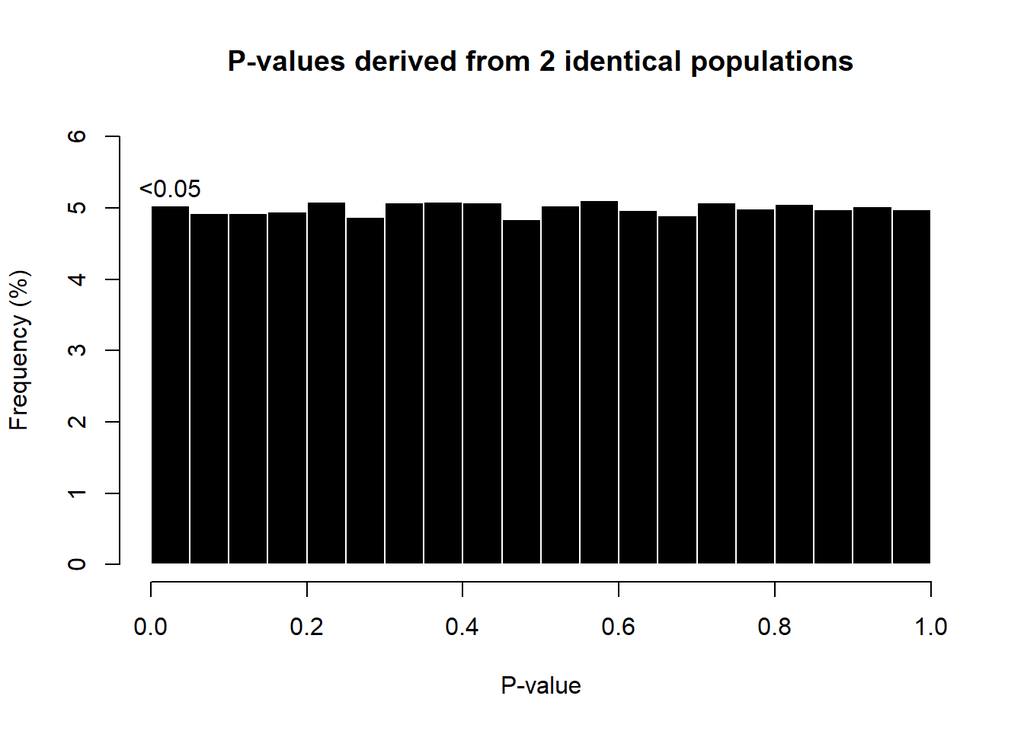

```r
#now I want the y axis to be %, so we will divide the count of each bar by the total count
h$density = h$counts/sum(h$counts)*100
# now lets plot it
plot(h,freq=FALSE, main="P-values derived from 2 identical populations", xlab="P-value", ylab="Frequency (%)", col="black", border="white", labels=c("<0.05", rep(NA,19)), ylim=c(0,6) )
```

The histogram above has the P-values calculated from our test along the X (bottom) axis, and the % of cases for that value along the Y (vertical) axis. The histogram demonstrates that even when the populations (not the samples) are identical we can still generate extreme data that passes our 0.05 threshold 5% of the time. So, our 0.05 P-value threshold means we are willing to accept a 5% risk of wrongly concluding that there **is** a difference, when in fact there is **not**.

We must also remember that the statistical power of a study directly affects our ability to accurately test our hypothesis. See [AMP lesson 1](https://michael-bar.github.io/AMP-1-distributions/AMP_distributions_lesson.html#) for more details.

Now we understand the hypothesis part of the RCT, let us move on to the other key part, randomization.

### 1.3.3 Randomisation in RCTs

Why do we randomize in an RCT? And why would we not want farmers to self-select whether they are treatment or control? It essentially comes down to eliminating **bias** and distributing **co-variates** equally:

- Randomization bias - bias can be due to poor randomization resulting in *unbalanced T/C groups* (e.g. we have more control than treatment farmers in District X).
- Selection bias - bias would also result if we were to allow farmers to assign themselves to T/C groups. This is because there might be an unobservable reason why farmers are choosing T/C groups. For example, wealthier farmers might have more risk appetite and therefore select themselves into treatment groups more,
  - Both of these will lead to what is called **confounding bias**, this means it will be difficult to untangle effects from selection/randomization bias vs. the actual intervention.
- However, if each participant has an equal chance of being randomly assigned to a T/C group then we can use probability theory to understand an intervention. Note that having an analyst randomize farmers properly will eliminate the types of bias above. This will result in co-variates (such as risk appetite) being spread evenly to T and C groups. It is this spreading of co-variates that allows us to understand causality.

It is therefore important to select treatment and control groups *totally randomly*, the best way to achieve this is by letting R to the work for you, as in the below code:

```r
#lets first make up a fake list of farmer IDS

df = data.frame("OAFID"=seq(1,1000), "values"=rnorm(1000))


# I have made this function for you to use
# it needs to be given a dataframe and a list of options
# Options might be "treatment" and "control", or if there are more than 2 options then it might be "Control", "treatment1", "treatment2""
## NEW FUNCTION
RCT_random = function(dataframey, values_to_add){
  dataframey$values_to_add[sample(1:nrow(dataframey), nrow(dataframey), FALSE)] <- rep(values_to_add)
  colnames(dataframey)[which(colnames(dataframey)=="values_to_add")] = "Status"
  return(dataframey) }


df_new = RCT_random(df, c("Treatment","Control"))

#we now have evenly split Treatment and control
```

We have now taken our original dataframe:

```r
head(df)
```

```
  OAFID     values
1     1 -0.8986245
2     2 -1.5975586
3     3  0.5416412
4     4 -1.6719577
5     5 -0.5882382
6     6 -2.2306800
```

And randomly assigned T and C status to them with my function “RCT_random”:

```r
head(df_new)
```

```
  OAFID     values    Status
1     1 -0.8986245   Control
2     2 -1.5975586   Control
3     3  0.5416412 Treatment
4     4 -1.6719577 Treatment
5     5 -0.5882382   Control
6     6 -2.2306800   Control
```

> Let’s look at some examples of randomisation strategies below and try to decide whether they are proper or improper randomisation:
1. Farmers are allowed to decide whether to be in a treatment or control group
2. Any farmer with a national ID number ending in an odd number is assigned to treatment, any farmer with an ID ending in an even number is assigned to control.
3. Farmers east of the OAF office are assigned to control, farmers west of the OAF office are assigned to treatment
4. We flip a coin to decide whether a farmer is control or treatment

## 1.4 Cluster randomised trials

Often at One Acre Fund we will be running *cluster randomised trials* rather than *randomised controlled trials*. The difference between these two trials lies in the **unit of inference** and the **unit of randomisation**. A traditional RCT seeks to assign treatment and control status at the individual level, whilst a cluster RCT seeks to assign treatment and control at a cluster level. A **cluster** is any group of individuals with shared characteristics that cannot be randomized away, or where there is significant risk of *contamination* of control/treatment status. For example, if we were to assign some members of a lending group to treatment and some to control and test the impact of a new training on maize yields then there is a fair chance that communication between members of the same group would mean our control farmers could pick up the new training. This would weaken our RCT and we would therefore want to randomize at the group or site level (so all members of certain groups or sites are assigned T/C status).

A general issue with lending groups at OAF is that farmers self-select into groups, thus generating selection bias. It is therefore rare that we would ever randomize at the individual level.

When analyzing data from a cluster RCT it is important to summarize the data by cluster. This means we match the unit of randomization to the unit of analysis. For example, if we randomize groups into treatment and control and want to understand the effect of an intervention on maize yields then we would want to summarize the farmers by group, so that we have the group average maize yield. I have included some R code below to show how to do this:

This is our raw data, broken down at the farmer level:

```r
#make some data
df = data.frame(FarmerID=seq(1,100), Maize_yield=rnorm(100,500,50),  group_name=c("farmers_first","farmers_second","farmers_third","farmers_last"), District=c("A","B"))

library(knitr)
kable(df[1:9,], format="markdown", align="c")
```

| FarmerID | Maize_yield | group_name | District |
| --- | --- | --- | --- |
| 1 | 498.7159 | farmers_first | A |
| 2 | 493.3556 | farmers_second | B |
| 3 | 486.3326 | farmers_third | A |
| 4 | 530.4334 | farmers_last | B |
| 5 | 552.6773 | farmers_first | A |
| 6 | 505.3134 | farmers_second | B |
| 7 | 504.9707 | farmers_third | A |
| 8 | 459.7205 | farmers_last | B |
| 9 | 583.6720 | farmers_first | A |

In total we have 100 rows of data. Now let us summarize it by group_name:

```r
library(dplyr) # we need this for the %>%
# we call %>% "piping"
# we can pipe an object to a new function to simplify work
# so below we are taking df and piping it to a function that will group our data by "group name". Once we have grouped our data we will pipe it again to smmarise_each which will try to calculate the mean of each column in our dataframe. This final object is then saved as sum_df
sum_df = df %>% group_by(group_name) %>% summarise_each(funs(mean))

#kable makes a pretty table in r markdown HTMLs
kable(sum_df, format="markdown", align="c")
```

| group_name | FarmerID | Maize_yield | District |
| --- | --- | --- | --- |
| farmers_first | 49 | 508.3804 | NA |
| farmers_last | 52 | 516.7991 | NA |
| farmers_second | 50 | 491.4837 | NA |
| farmers_third | 51 | 482.1265 | NA |

We now have the average maize yield for each of our four groups (“farmers_first”, “farmers_second”, “farmers_third”, “farmers_last”). Note that we also have the “average” ID number, which is obviously nonsense, also note that our non-numeric columns (like District) have been replaced with NAs (as we cannot average characters). Finally, be aware that if one of our numeric columns were set to class “character” or class “factor” rather than class “numeric” then it would also fail to average them. You can examine the class of a column like this:

```r
class(df$Maize_yield)
```

```
## [1] "numeric"
```

or of all columns like this:

```r
#apply the command "class" to all of df
lapply(df, class)
```

```
## $FarmerID
## [1] "integer"
##
## $Maize_yield
## [1] "numeric"
##
## $group_name
## [1] "factor"
##
## $District
## [1] "factor"
```

We can set the class of a column like this:

```
df$Maize_yield <- as.numeric(df$Maize_yield)

# we also have:
# as.character()
# as.factor()
```

Finally, we can manually manipulate our data if we want specific new metrics:

```r
library(plyr)
sum_df2 <-  ddply(df, c("group_name"), summarise,  average_yield= mean(Maize_yield), stdev_yield= sd(Maize_yield))

head(sum_df2)
```

```
      group_name average_yield stdev_yield
1  farmers_first      508.3804    43.11659
2   farmers_last      516.7991    37.53161
3 farmers_second      491.4837    50.16247
4  farmers_third      482.1265    52.55206
```

# 2 Outliers

An outlier is a data point which lies outside the main distribution and may signal data recorded or entered incorrectly. The problem with outliers is trying to distinguish real data that is just unexpected (but is valid) and data which is incorrect due to enumerator survey error.

We can visualize data with a beeswarm plot, note the potential outliers at the top of the plot:

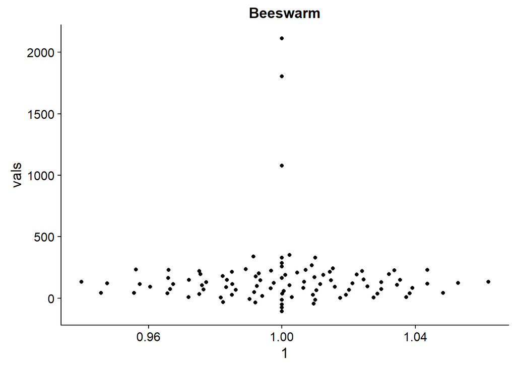

```r
set.seed(112)
#make some data
df = data.frame(ID=seq(1,100), vals=rnorm(100,100,100))
#add some outliers
df$vals[98:100] = rnorm(3,1000,1000)


library(ggbeeswarm)
ggplot(df) +  geom_beeswarm(aes(x=1,y=vals)) + ggtitle("Beeswarm")
```

We can also try to define outliers mathematically, the boxplot uses a simple formula to identify potential outliers, I have included a function below that will use this logic to find outliers:

```r
find_outliers <- function(data_to_test){

      IQR<- quantile(data_to_test, 0.75, na.rm=TRUE)[[1]] - quantile(data_to_test, 0.25, na.rm=TRUE)[[1]]
      cutoff = subset(data_to_test, data_to_test <=  quantile(data_to_test, 0.25, na.rm=TRUE)-(IQR*1.5) )
      cutoff2 = subset(data_to_test, data_to_test >=   quantile(data_to_test, 0.75, na.rm=TRUE)+(IQR*1.5) )
      ret = c(cutoff,cutoff2)
      return(ret)
}

find_outliers(df$vals)
```

```
## [1] 2111.791 1077.596 1805.064
```

These tools can help us identify potential outliers but cannot definitively tell us whether a data point is real or not. When we assign something as an outlier we are making a big assumption about the underlying distribution of data and what *we* think it should look like. There is always a danger that our assumption is wrong or that we have biases leading us to incorrectly label things as outliers. There is no easy solution to this, and often it will be contextual knowledge which we use to identify real outliers, for example, it is likely that a farmer reporting 10000 Kg of fertilizer per acre is an enumerator error, this farmer can be removed from the data, or resurveyed. However a farmer reporting 1000 Kg of fertilizer per acre may or may not be an outlier, in this case we can still flag them for resurvey, but it is more difficult to know whether to remove them from the data.

If we are confident in identifying outliers, they can be removed. It is generally good practice to report P-values and regression results with data that includes outliers and data that excludes outliers. We can then see if our conclusion is robust to outliers, i.e. does our conclusion change if we have (or do not have) outlying farmers included.

It is good practice to test for outliers regularly during an RCT (not just afterwards), this will allow us to identify potential errors early, and have the farmers resurveyed, or the survey altered, in good time.

# 3 Scientific writing

Finally, an RCT represents a significant investment of time and resources by field staff, analysts and you! It is therefore important to record our analysis clearly and transparently. This will enable future staff to examine our work and so extend its reach and usefulness.

There are a few elements to scientific writing. We must include a “methods” section, which explains what analysis we have done and how the data was treated (this is a good place to explain why outliers were removed and which statistical tests we have used). The methods is also where we justify our use of techniques, for example why we have used linear regression.

We can also include an appendix, the aim of the appendix is to make our work clear for other analysts without cluttering the main body of text (which might discourage non-technicals from reading our work). Therefore we can put plots diagnosing distributions (QQplots, etc), regressions or models in the appendix.

## 3.1 R-markdown crash course

Finally, we can use R-markdown. R-markdown is part of R-studio and allows us to present code, data and results all in one place for complete transparency. Writing in R-markdown makes your work accessible to non-technical people (who want to skip code and just see the results), and technical people who will want to see your code. These lessons are made in R-markdown and hopefully demonstrate how useful it is!

To use R-markdown you will first need to install R and R-studio. From R-Studio you will then need to install the packages rmarkdown and knitr from the tools > install packages command in the toolbar. Please see [this](http://rmarkdown.rstudio.com/authoring_quick_tour.html) link for an introduction to R-markdown.

A simple R-markdown file example can be seen [here](https://drive.google.com/a/oneacrefund.org/file/d/0B3_WyX1D8qwMYjRNSURWQUt3TU0/view?usp=sharing) (please download it and open in Rstudio). R-markdown files have the extension .Rmd, and when “knitted” will become either a HTML or a PDF that is easily share-able. Try “knitting” the downloaded file before proceeding:

[figure not shown]

Here is the knit button in Rstudio.

I would like you to spend some time becoming familiar with R-markdown, to start you can use the simple example above. Later you can use this [scientific writing R-markdown template](https://drive.google.com/a/oneacrefund.org/file/d/0B3_WyX1D8qwMRE5yX2FJQlJUOTg/view?usp=sharing).

## 3.2 Summary

We have now seen the key parts of an RCT, how to use R in designing an RCT, how to summarize data and finally how to present our results in a format that will ensure maximum usage!

## 3.3 Best practices and talking points

> The best practices when analysing an RCT:
- Know what your hypothesis is!
- Make sure your Treatment and Control groups are truly random
- Know what *difference* in treatment and control you are looking for, and what hypothesis test you need!
- Know your statistical power and sample size before and after a trial - see [AMP lesson 1](https://michael-bar.github.io/AMP-1-distributions/AMP_distributions_lesson.html#)
- Understand what your cluster is, and match it to your analysis!
- Check for data outliers *during* a trial, and try to fix them.

> The best practices when communicating an RCT:
- Scientific writing will make your work more impactful.
- Try to use R-markdown to make your work accessible to technical and non-technical people alike.
- Remember the ideas around graph presentation we covered last lesson (“simple graphs, but true to the data”).